# Homework 09

Use only when the user explicitly invokes SVM-analysis by name. Guides a cross-validated SVM classification analysis and a one-page report. Never load or apply it automatically.

The kernel-tuning question moved here from Homework 08. A solution for Question 1 will be available after Monday, October 26, 2026. No solution will be provided for Question 2.

## Question 1: Choosing an SVM kernel

Use `saheart.csv` from the combined ZIP. As in Homework 7, predict `chd` using the same nine predictors, coding `famhist` as 1 for `Absent` and 2 for `Present`.

Compare SVMs with a linear kernel, polynomial kernels of degrees 2 (quadratic), 3, and 4, and a radial basis kernel. Choose **no more than 20 candidate settings in total** across these kernels. Vary the cost $C$ for each kernel and the radial scale $\gamma$ for the radial kernel. State any other kernel settings you hold fixed.

Divide the observations into five folds yourself and use the same folds for all candidates. Standardize predictors using only the fitting observations in each fold. Report the candidate settings and their mean cross-validation misclassification rates. Which kernel and settings do you prefer? Give a brief justification.

## Solution to Question 1

I use the nine predictors in `saheart.csv`, coding `famhist` as 1 for `Absent` and 2 for `Present`. The response is the binary variable `chd`. The folds are created once and reused for every candidate. Within each fold, the centering and scaling constants are calculated from the fitting observations only, so the validation observations do not influence preprocessing.

```r
library(e1071)
library(knitr)
set.seed(43209)

heart <- read.csv("data/saheart.csv")
heart$famhist <- ifelse(heart$famhist == "Absent", 1, 2)

predictor_names <- setdiff(names(heart), "chd")
X <- as.matrix(heart[, predictor_names])
y <- factor(heart$chd, levels = c(0, 1))
n <- nrow(X)

stopifnot(n == 462, ncol(X) == 9, all(X[, "famhist"] %in% c(1, 2)))

# The same five folds are used for every candidate model.
fold_id <- sample(rep(1:5, length.out = n))
table(fold_id)
```

```
fold_id
 1  2  3  4  5
93 93 92 92 92
```

The candidate grid is deliberately capped at 20 settings. The radial kernel has two values of $C$ and two values of $\gamma$; therefore its $C$ and $\gamma$ effects are assessed jointly.

```r
cost_values <- c(0.1, 1, 10, 100)

settings <- rbind(
  data.frame(
    kernel = "linear", degree = NA_integer_,
    C = cost_values, gamma = NA_real_
  ),
  do.call(
    rbind,
    lapply(
      2:4,
      function(degree) {
        data.frame(
          kernel = "polynomial", degree = degree,
          C = cost_values, gamma = NA_real_
        )
      }
    )
  ),
  data.frame(
    kernel = "radial", degree = NA_integer_,
    C = rep(c(1, 10), each = 2),
    gamma = rep(c(0.01, 0.1), 2)
  )
)

stopifnot(nrow(settings) == 20)
settings
```

```
       kernel degree     C gamma
1      linear     NA   0.1    NA
2      linear     NA   1.0    NA
3      linear     NA  10.0    NA
4      linear     NA 100.0    NA
5  polynomial      2   0.1    NA
6  polynomial      2   1.0    NA
7  polynomial      2  10.0    NA
8  polynomial      2 100.0    NA
9  polynomial      3   0.1    NA
10 polynomial      3   1.0    NA
11 polynomial      3  10.0    NA
12 polynomial      3 100.0    NA
13 polynomial      4   0.1    NA
14 polynomial      4   1.0    NA
15 polynomial      4  10.0    NA
16 polynomial      4 100.0    NA
17     radial     NA   1.0  0.01
18     radial     NA   1.0  0.10
19     radial     NA  10.0  0.01
20     radial     NA  10.0  0.10
```

The following helper standardizes both the fitting and validation matrices using the fitting-fold means and standard deviations. The cross-validation function returns the misclassification rate in each validation fold and their mean.

```r
standardize_fold <- function(x_train, x_validation) {
  center <- colMeans(x_train)
  scale <- apply(x_train, 2, sd)

  list(
    train = sweep(
      sweep(x_train, 2, center, "-"), 2, scale, "/"
    ),
    validation = sweep(
      sweep(x_validation, 2, center, "-"), 2, scale, "/"
    )
  )
}

fit_candidate <- function(setting, x_train, y_train) {
  if (setting$kernel == "linear") {
    return(
      svm(
        x = x_train, y = y_train,
        kernel = "linear", scale = FALSE, cost = setting$C
      )
    )
  }

  if (setting$kernel == "polynomial") {
    return(
      svm(
        x = x_train, y = y_train,
        kernel = "polynomial", degree = setting$degree,
        scale = FALSE, coef0 = 1, cost = setting$C
      )
    )
  }

  svm(
    x = x_train, y = y_train,
    kernel = "radial", scale = FALSE, gamma = setting$gamma,
    cost = setting$C
  )
}

cross_validate <- function(setting) {
  fold_errors <- numeric(5)

  for (fold in 1:5) {
    validation <- fold_id == fold
    fitting <- !validation

    scaled <- standardize_fold(
      X[fitting, , drop = FALSE],
      X[validation, , drop = FALSE]
    )
    fit <- fit_candidate(setting, scaled$train, y[fitting])
    prediction <- predict(fit, scaled$validation)
    fold_errors[fold] <- mean(prediction != y[validation])
  }

  c(fold_errors, mean_error = mean(fold_errors))
}

cv_results <- lapply(
  seq_len(nrow(settings)),
  function(i) cross_validate(settings[i, , drop = FALSE])
)

results <- cbind(settings, do.call(rbind, cv_results))
names(results)[(ncol(settings) + 1):ncol(results)] <-
  c(paste0("fold_", 1:5), "mean_error")

results <- results[order(results$mean_error), ]
rownames(results) <- NULL

display_results <- results
display_results$mean_error <- round(display_results$mean_error, 4)
display_results[, paste0("fold_", 1:5)] <-
  round(display_results[, paste0("fold_", 1:5)], 4)

kable(display_results, caption = "Five-fold validation errors for all 20 candidates")
```

Five-fold validation errors for all 20 candidates

| kernel | degree | C | gamma | fold_1 | fold_2 | fold_3 | fold_4 | fold_5 | mean_error |
| --- | --- | --- | --- | --- | --- | --- | --- | --- | --- |
| radial | NA | 10.0 | 0.01 | 0.3118 | 0.2581 | 0.2283 | 0.2283 | 0.2283 | 0.2509 |
| polynomial | 2 | 1.0 | NA | 0.3333 | 0.2581 | 0.2065 | 0.2391 | 0.2500 | 0.2574 |
| polynomial | 2 | 0.1 | NA | 0.3333 | 0.2796 | 0.2717 | 0.2065 | 0.2391 | 0.2661 |
| polynomial | 3 | 0.1 | NA | 0.3656 | 0.2581 | 0.2717 | 0.2283 | 0.2500 | 0.2747 |
| linear | NA | 0.1 | NA | 0.3118 | 0.2688 | 0.3043 | 0.2174 | 0.2717 | 0.2748 |
| radial | NA | 1.0 | 0.01 | 0.3656 | 0.2796 | 0.2500 | 0.2174 | 0.2717 | 0.2769 |
| radial | NA | 1.0 | 0.10 | 0.3441 | 0.2581 | 0.2826 | 0.2283 | 0.2717 | 0.2770 |
| linear | NA | 1.0 | NA | 0.3333 | 0.2796 | 0.3043 | 0.2174 | 0.2717 | 0.2813 |
| linear | NA | 10.0 | NA | 0.3333 | 0.2796 | 0.3043 | 0.2174 | 0.2717 | 0.2813 |
| linear | NA | 100.0 | NA | 0.3333 | 0.2796 | 0.3043 | 0.2174 | 0.2717 | 0.2813 |
| polynomial | 2 | 10.0 | NA | 0.3871 | 0.2796 | 0.2609 | 0.2500 | 0.2500 | 0.2855 |
| polynomial | 4 | 0.1 | NA | 0.3656 | 0.3118 | 0.2717 | 0.2283 | 0.2717 | 0.2898 |
| polynomial | 3 | 1.0 | NA | 0.3656 | 0.2903 | 0.3152 | 0.2391 | 0.2826 | 0.2986 |
| polynomial | 2 | 100.0 | NA | 0.3871 | 0.3011 | 0.2826 | 0.2500 | 0.2826 | 0.3007 |
| polynomial | 4 | 1.0 | NA | 0.3548 | 0.3548 | 0.3370 | 0.2826 | 0.3043 | 0.3267 |
| radial | NA | 10.0 | 0.10 | 0.3656 | 0.3333 | 0.3261 | 0.3043 | 0.3043 | 0.3267 |
| polynomial | 3 | 10.0 | NA | 0.4194 | 0.3333 | 0.3370 | 0.2935 | 0.3043 | 0.3375 |
| polynomial | 3 | 100.0 | NA | 0.4946 | 0.3656 | 0.3261 | 0.3370 | 0.3261 | 0.3699 |
| polynomial | 4 | 10.0 | NA | 0.4301 | 0.4516 | 0.3913 | 0.2935 | 0.3261 | 0.3785 |
| polynomial | 4 | 100.0 | NA | 0.4839 | 0.4624 | 0.3804 | 0.2935 | 0.3696 | 0.3979 |

The radial SVM with $C=10$ and $\gamma=0.01$ performs best among the 20 candidates, with the smallest mean validation misclassification rate. Its mean error is approximately 0.251, so this is the preferred model.

```r
best <- results[1, ]
best
```

```
  kernel degree  C gamma   fold_1    fold_2    fold_3    fold_4    fold_5
1 radial     NA 10  0.01 0.311828 0.2580645 0.2282609 0.2282609 0.2282609
  mean_error
1   0.250935
```

The important details are that the folds are fixed and reused, scaling is fit separately inside each training fold, and the radial kernel varies both $C$ and $\gamma$.

## Question 2: Write and use a short SVM analysis skill

In Homework 8, you reviewed another student’s skill. Review the comments and suggestions you received on your own Homework 7 skill. Use what you learned from both sides of the peer review to write a new, shorter skill for SVM model fitting.

**Write the skill by hand.** Create a `SKILL.md` with a short name and description in YAML frontmatter. Write the entire file yourself, without asking AI to draft or edit it. The instruction body after the closing `---` of the frontmatter must be **no more than 50 lines**, including blank lines. Keep the skill independent of any particular dataset, variable names, or observed results, and load it only when you explicitly invoke it.

Your skill should direct the agent to:

1. judge whether the data are suitable for an SVM analysis;
2. choose which kernels to consider and explain why;
3. identify tuning parameters and a method for tuning them;
4. choose an evaluation method that supports selecting a final model;
5. require a compact figure and table that justify the choices;
6. interpret the fit and report the key numerical results; and
7. prioritize the evidence needed to justify the final model in **no more than one printed page at 11-point font**.

**Apply the skill.** Explicitly invoke your skill to analyze `saheart.csv`, using the same response, nine predictors, and `famhist` coding as in Question 1. Provide these data details when invoking the skill, not in the skill itself. Let the skill guide the analysis, then check the resulting report and calculations.

**Submit the results.** Include the one-page, 11-point analysis report in your Homework 09 submission and append the complete contents of your `SKILL.md` afterward. The appended skill is outside the one-page limit.

## Applying `SVM-analysis` to `saheart.csv`

The data are suitable for SVM classification: there are 462 complete observations, nine numerical predictors after coding `famhist`, and the binary response `chd`. I use the same 20 candidate settings as in Question 1. I reserve a stratified 25% test set, use stratified 10-fold cross-validation on the remaining training data, and standardize within each training fold. The seed is 43209.

The degree-3 polynomial with $C=0.1$ has the lowest cross-validation error, 0.2746. However, the simpler linear model with $C=0.1$ is within one standard error of that result, so I select the linear model. Its test misclassification rate is 0.2759.

```r
library(ggplot2)
set.seed(43209)

heart_q2 <- read.csv("data/saheart.csv")
heart_q2$famhist <- ifelse(heart_q2$famhist == "Absent", 1, 2)
X_q2 <- as.matrix(heart_q2[setdiff(names(heart_q2), "chd")])
y_q2 <- factor(heart_q2$chd, levels = c(0, 1))

class_indices <- split(seq_len(nrow(X_q2)), y_q2)
test_id_q2 <- unlist(lapply(
  class_indices,
  function(i) sample(i, ceiling(0.25 * length(i)))
))
train_id_q2 <- setdiff(seq_len(nrow(X_q2)), test_id_q2)
y_train_q2 <- y_q2[train_id_q2]

fold_id_q2 <- integer(length(train_id_q2))
for (class in levels(y_train_q2)) {
  class_rows <- which(y_train_q2 == class)
  fold_id_q2[class_rows] <- sample(
    rep(1:10, length.out = length(class_rows))
  )
}

scale_q2 <- function(x_train, x_validation) {
  center <- colMeans(x_train)
  scale <- apply(x_train, 2, sd)
  list(
    train = sweep(sweep(x_train, 2, center, "-"), 2, scale, "/"),
    validation = sweep(
      sweep(x_validation, 2, center, "-"), 2, scale, "/"
    )
  )
}

fit_q2 <- function(setting, x_train, y_train) {
  if (setting$kernel == "linear") {
    return(svm(
      x_train, y_train, kernel = "linear",
      scale = FALSE, cost = setting$C
    ))
  }
  if (setting$kernel == "polynomial") {
    return(svm(
      x_train, y_train, kernel = "polynomial",
      degree = setting$degree, scale = FALSE,
      coef0 = 1, cost = setting$C
    ))
  }
  svm(
    x_train, y_train, kernel = "radial",
    scale = FALSE, gamma = setting$gamma, cost = setting$C
  )
}

cv_q2 <- function(setting) {
  errors <- numeric(10)
  for (fold in 1:10) {
    validation <- fold_id_q2 == fold
    scaled <- scale_q2(
      X_q2[train_id_q2[!validation], , drop = FALSE],
      X_q2[train_id_q2[validation], , drop = FALSE]
    )
    fit <- fit_q2(setting, scaled$train, y_train_q2[!validation])
    errors[fold] <- mean(
      predict(fit, scaled$validation) != y_train_q2[validation]
    )
  }
  c(mean_error = mean(errors), se = sd(errors) / sqrt(10))
}

q2_cv <- cbind(
  settings,
  do.call(rbind, lapply(
    seq_len(nrow(settings)),
    function(i) cv_q2(settings[i, , drop = FALSE])
  ))
)
q2_cv <- q2_cv[order(q2_cv$mean_error), ]
rownames(q2_cv) <- NULL

raw_best_q2 <- q2_cv[1, ]
one_se_q2 <- q2_cv[
  q2_cv$mean_error <= raw_best_q2$mean_error + raw_best_q2$se,
]
one_se_q2$simplicity <- ifelse(
  one_se_q2$kernel == "linear", 1,
  ifelse(one_se_q2$kernel == "polynomial",
         2 + one_se_q2$degree, 6)
)
selected_q2 <- one_se_q2[
  order(one_se_q2$simplicity, one_se_q2$C), ][1, ]
q2_cv$selected <- FALSE
selected_row_q2 <- match(rownames(selected_q2), rownames(q2_cv))
q2_cv$selected[selected_row_q2] <- TRUE

kable(
  q2_cv[c("selected", "kernel", "degree", "C", "gamma",
          "mean_error", "se")],
  digits = 4,
  caption = "Question 2: ten-fold CV results for all 20 candidates"
)
```

Question 2: ten-fold CV results for all 20 candidates

| selected | kernel | degree | C | gamma | mean_error | se |
| --- | --- | --- | --- | --- | --- | --- |
| FALSE | polynomial | 3 | 0.1 | NA | 0.2746 | 0.0234 |
| FALSE | radial | NA | 10.0 | 0.01 | 0.2775 | 0.0130 |
| FALSE | polynomial | 2 | 0.1 | NA | 0.2832 | 0.0206 |
| FALSE | radial | NA | 1.0 | 0.10 | 0.2833 | 0.0178 |
| FALSE | radial | NA | 1.0 | 0.01 | 0.2859 | 0.0147 |
| FALSE | polynomial | 2 | 100.0 | NA | 0.2861 | 0.0196 |
| FALSE | polynomial | 2 | 1.0 | NA | 0.2862 | 0.0240 |
| FALSE | linear | NA | 1.0 | NA | 0.2887 | 0.0260 |
| FALSE | linear | NA | 10.0 | NA | 0.2887 | 0.0260 |
| FALSE | linear | NA | 100.0 | NA | 0.2887 | 0.0260 |
| TRUE | linear | NA | 0.1 | NA | 0.2887 | 0.0232 |
| FALSE | polynomial | 2 | 10.0 | NA | 0.2919 | 0.0239 |
| FALSE | polynomial | 4 | 0.1 | NA | 0.2947 | 0.0237 |
| FALSE | polynomial | 3 | 1.0 | NA | 0.3178 | 0.0190 |
| FALSE | radial | NA | 10.0 | 0.10 | 0.3411 | 0.0197 |
| FALSE | polynomial | 4 | 1.0 | NA | 0.3467 | 0.0174 |
| FALSE | polynomial | 3 | 10.0 | NA | 0.3612 | 0.0133 |
| FALSE | polynomial | 3 | 100.0 | NA | 0.3697 | 0.0142 |
| FALSE | polynomial | 4 | 10.0 | NA | 0.3726 | 0.0247 |
| FALSE | polynomial | 4 | 100.0 | NA | 0.3844 | 0.0204 |

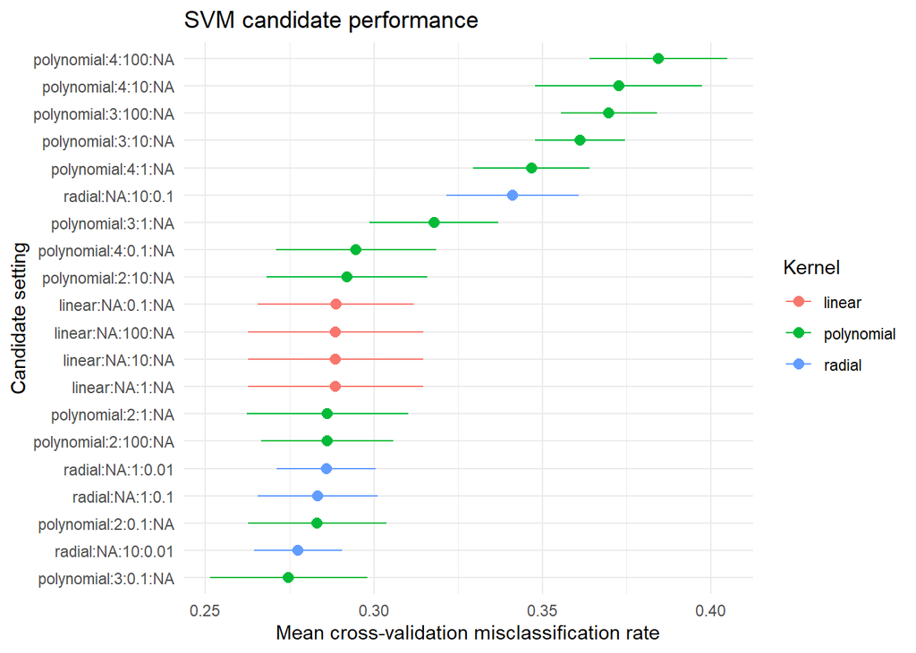

```r
ggplot(q2_cv, aes(
  x = reorder(paste(kernel, degree, C, gamma, sep = ":"),
              mean_error),
  y = mean_error, color = kernel
)) +
  geom_point(size = 2.5) +
  geom_errorbar(
    aes(ymin = mean_error - se, ymax = mean_error + se),
    width = 0
  ) +
  labs(
    x = "Candidate setting",
    y = "Mean cross-validation misclassification rate",
    color = "Kernel",
    title = "SVM candidate performance"
  ) +
  coord_flip() +
  theme_minimal()
```

```r
scaled_final_q2 <- scale_q2(
  X_q2[train_id_q2, , drop = FALSE],
  X_q2[test_id_q2, , drop = FALSE]
)
final_q2 <- fit_q2(
  selected_q2, scaled_final_q2$train, y_train_q2
)
test_prediction_q2 <- predict(final_q2, scaled_final_q2$validation)
test_confusion_q2 <- table(
  Observed = y_q2[test_id_q2],
  Predicted = test_prediction_q2
)
test_error_q2 <- mean(test_prediction_q2 != y_q2[test_id_q2])
test_size_q2 <- length(test_prediction_q2)
test_error_se_q2 <- sqrt(
  test_error_q2 * (1 - test_error_q2) / test_size_q2
)
class_priors_q2 <- prop.table(table(y_train_q2))

class_priors_q2
```

```
y_train_q2
        0         1
0.6531792 0.3468208
```

```r
test_confusion_q2
```

```
        Predicted
Observed  0  1
       0 65 11
       1 21 19
```

```r
list(
  error = test_error_q2,
  standard_error = test_error_se_q2,
  size = test_size_q2
)
```

```
$error
[1] 0.2758621

$standard_error
[1] 0.04149805

$size
[1] 116
```

The empirical class priors in the training data are printed by the code above. The selected linear model has $C=0.1$. The held-out test confusion matrix has rows for observed classes and columns for predicted classes:

```
         Predicted
Observed   0   1
       0  65  11
       1  21  19
```

Thus, the test error is $32/116=0.2759$, with binomial standard error approximately 0.0415. The test set is small enough that this estimate is uncertain; the cross-validation table and error-bar figure provide the main evidence for model selection.

## Appendix: `SKILL.md`

# SVM-analysis

Apply this skill only when the user explicitly asks for it by name. The user supplies the dataset, response, predictors, coding, and random seed in the request. Do not assume any variable names or expected results.

## Scope

Use only SVM with either of these kernels: linear, polynomial, radial. For cost and gamma, check if there is a grid to be explored, if not, then use a reasonable grid and do not test more than 30 settings in total unless requested. Do not use other classifier families. Work in R.

## Analysis rules

1. Set the seed once and report it. Make no data-dependent choices before the split.
2. Reserve a test set (about 25 percent, stratified by class) before any modeling. Never use it for model selection, tuning, or revising these instructions.
3. Build one fixed set of cross-validation folds (10-fold, or 5-fold if a class is small) on the training data. Use these same folds for every candidate and every tuning setting.
4. Candidates must include SVM with either of these kernels: linear, polynomial, radial. before starting check if the data is suitable for SVM, if not, report the issue and do not continue. If the user has provided a grid of cost and gamma values, use it. If not, create a reasonable grid of cost and gamma values to explore, but do not test more than 30 settings in total unless requested. For chooseing kernels, you can be flexible, no need to test all costs on all kernels for example, but you need to justify why you have chosen specific kernels and cost/gamma values. If a fit fails, report the failure and exclude that candidate. Do not silently regularize.
5. Estimate all preprocessing (centering, scaling) from the training portion of each fold only, then apply it unchanged to that fold’s validation part. Makes sure to scale the data before applying SVM.
6. If a class covariance matrix is singular or a fit fails, report the failure and exclude that candidate. Do not silently regularize.
7. Compare candidates by cross-validated misclassification rate. Select the lowest; if the difference is smaller than one standard error, prefer the simpler model. also consider other evaluation methods if it suits, and certainly if user requested.
8. Refit the selected model and its preprocessing on all training data. Evaluate it once on the test set and report the test misclassification rate with a binomial standard error or interval.
9. Every number in the report must come from executed code. Never invent or estimate results. Save the code you ran.

## Report requirements

Produce a report of at most one printed page at 11-point font, then check that it fits on one page. It must contain: - A short header: goal, data intodution and size, class counts, seed. - table 1: models being compared. - table 2: cross-validated error for every candidate, with the selected model marked, plus the final test error. - One figure: cross-validated error with error bars for the candidates or tuning values. Label axes in words, give a title and a legend, use colorblind-safe colors, and keep text readable at page size. - Numerical fitting results: selected settings, class priors, test confusion matrix (observed in rows, predicted in columns), and test error. - Brief text on the candidate models, cross-validation procedure and results, conclusion, selected model, estimated prediction error, main findings, and limitations. - Report the empirical class priors. - Report the final test misclassification rate with a binomial standard error or confidence interval.

## Style

Be concise. Take all variable names and conclusions from the user’s data and the executed results, never from this file. State any assumptions the user should check, and report any deviation from these rules.